# Cars4U

#### Treated all missing values.

```python
df.info()
```

```
<class 'pandas.core.frame.DataFrame'>
RangeIndex: 6017 entries, 0 to 6016
Data columns (total 12 columns):
 #   Column             Non-Null Count  Dtype
---  ------             --------------  -----
 0   Name               6017 non-null   object
 1   Location           6017 non-null   object
 2   Year               6017 non-null   int64
 3   Kilometers_Driven  6017 non-null   int64
 4   Fuel_Type          6017 non-null   object
 5   Transmission       6017 non-null   object
 6   Owner_Type         6017 non-null   object
 7   Mileage            6017 non-null   object
 8   Engine             6017 non-null   float64
 9   Power              6017 non-null   float64
 10  Seats              6017 non-null   float64
 11  Price              6017 non-null   float64
dtypes: float64(4), int64(2), object(6)
memory usage: 564.2+ KB
```

```python
df.describe(include='all').T
```

|  | count | unique | top | freq | mean | std | min | 25% | 50% | 75% | max |
| --- | --- | --- | --- | --- | --- | --- | --- | --- | --- | --- | --- |
| Name | 6017 | 1874 | Mahindra XUV500 W8 2WD | 49 | NaN | NaN | NaN | NaN | NaN | NaN | NaN |
| Location | 6017 | 11 | Mumbai | 789 | NaN | NaN | NaN | NaN | NaN | NaN | NaN |
| Year | 6017.0 | NaN | NaN | NaN | 2013.358152 | 3.269967 | 1998.0 | 2011.0 | 2014.0 | 2016.0 | 2019.0 |
| Kilometers_Driven | 6017.0 | NaN | NaN | NaN | 58742.282034 | 91283.745583 | 171.0 | 34000.0 | 53000.0 | 73000.0 | 6500000.0 |
| Fuel_Type | 6017 | 4 | Diesel | 3205 | NaN | NaN | NaN | NaN | NaN | NaN | NaN |
| Transmission | 6017 | 2 | Manual | 4299 | NaN | NaN | NaN | NaN | NaN | NaN | NaN |
| Owner_Type | 6017 | 4 | First | 4927 | NaN | NaN | NaN | NaN | NaN | NaN | NaN |
| Mileage | 6017 | 442 | 18.9 kmpl | 172 | NaN | NaN | NaN | NaN | NaN | NaN | NaN |
| Engine | 6017.0 | NaN | NaN | NaN | 1621.504562 | 599.316375 | 624.0 | 1198.0 | 1493.0 | 1969.0 | 5998.0 |
| Power | 6017.0 | NaN | NaN | NaN | 112.902114 | 53.282014 | 34.2 | 78.0 | 97.7 | 138.03 | 560.0 |
| Seats | 6017.0 | NaN | NaN | NaN | 5.276882 | 0.806464 | 0.0 | 5.0 | 5.0 | 5.0 | 10.0 |
| Price | 6017.0 | NaN | NaN | NaN | 9.47834 | 11.189605 | 0.44 | 3.5 | 5.64 | 9.95 | 160.0 |

```python
df.head(6)
```

|  | Name | Location | Year | Kilometers_Driven | Fuel_Type | Transmission | Owner_Type | Mileage | Engine | Power | Seats | Price |
| --- | --- | --- | --- | --- | --- | --- | --- | --- | --- | --- | --- | --- |
| 0 | Maruti Wagon R LXI CNG | Mumbai | 2010 | 72000 | CNG | Manual | First | 26.6 km/kg | 998.0 | 58.16 | 5.0 | 1.75 |
| 1 | Hyundai Creta 1.6 CRDi SX Option | Pune | 2015 | 41000 | Diesel | Manual | First | 19.67 kmpl | 1582.0 | 126.20 | 5.0 | 12.50 |
| 2 | Honda Jazz V | Chennai | 2011 | 46000 | Petrol | Manual | First | 18.2 kmpl | 1199.0 | 88.70 | 5.0 | 4.50 |
| 3 | Maruti Ertiga VDI | Chennai | 2012 | 87000 | Diesel | Manual | First | 20.77 kmpl | 1248.0 | 88.76 | 7.0 | 6.00 |
| 4 | Audi A4 New 2.0 TDI Multitronic | Coimbatore | 2013 | 40670 | Diesel | Automatic | Second | 15.2 kmpl | 1968.0 | 140.80 | 5.0 | 17.74 |
| 5 | Hyundai EON LPG Era Plus Option | Hyderabad | 2012 | 75000 | LPG | Manual | First | 21.1 km/kg | 814.0 | 55.20 | 5.0 | 2.35 |

```python
def replace_mileage_units(mil_units):
    """
    This function look for km/kg and kmpl in the Mileage and replace them with empty space ("")
    """
    if isinstance(mil_units, str):  # checks if 'rmil_units' is a string
        if mil_units.endswith("km/kg"):
            return float(mil_units.replace("km/kg", ""))
        elif mil_units.endswith("kmpl"):
            return (
                float(mil_units.replace("kmpl", ""))
            )
    else:
        return np.nan
```

```python
# extract the amount of RAM
df["Mileage"] = df["Mileage"].apply(replace_mileage_units)
df['Mileage'].describe()
```

```
count    6017.000000
mean       18.134961
std         4.582289
min         0.000000
25%        15.170000
50%        18.150000
75%        21.100000
max        33.540000
Name: Mileage, dtype: float64
```

```python
# Changing Location","Fuel_Type","Transmission", "Owner_Type to categerical columns
cat_vars = ["Location","Fuel_Type","Transmission", "Owner_Type"]
for colname in cat_vars:
    df[colname] = df[colname].astype('category')
df.info()
```

```
<class 'pandas.core.frame.DataFrame'>
RangeIndex: 6017 entries, 0 to 6016
Data columns (total 12 columns):
 #   Column             Non-Null Count  Dtype
---  ------             --------------  -----
 0   Name               6017 non-null   object
 1   Location           6017 non-null   category
 2   Year               6017 non-null   int64
 3   Kilometers_Driven  6017 non-null   int64
 4   Fuel_Type          6017 non-null   category
 5   Transmission       6017 non-null   category
 6   Owner_Type         6017 non-null   category
 7   Mileage            6017 non-null   float64
 8   Engine             6017 non-null   float64
 9   Power              6017 non-null   float64
 10  Seats              6017 non-null   float64
 11  Price              6017 non-null   float64
dtypes: category(4), float64(5), int64(2), object(1)
memory usage: 400.6+ KB
```

```python
# list of categerial columns
cat_col = ["Location","Fuel_Type", "Transmission", "Owner_Type"]
#getting number of occurences of each column per category
for column in cat_col:
    print(df[column].value_counts())
    print("_" * 50)
```

```
Mumbai        789
Hyderabad     742
Kochi         651
Coimbatore    636
Pune          622
Delhi         554
Kolkata       535
Chennai       493
Jaipur        413
Bangalore     358
Ahmedabad     224
Name: Location, dtype: int64
__________________________________________________
Diesel    3205
Petrol    2746
CNG         56
LPG         10
Name: Fuel_Type, dtype: int64
__________________________________________________
Manual       4299
Automatic    1718
Name: Transmission, dtype: int64
__________________________________________________
First             4927
Second             968
Third              113
Fourth & Above       9
Name: Owner_Type, dtype: int64
__________________________________________________
```

#### Fourth & Above and Fuel_Type LPG can consider them are very few. It may be okay to remove them. But wanted to keep them to see how they effect the model.

```python
# Let's look at the statistical summary of the data
df.describe().T
```

|  | count | mean | std | min | 25% | 50% | 75% | max |
| --- | --- | --- | --- | --- | --- | --- | --- | --- |
| Year | 6017.0 | 2013.358152 | 3.269967 | 1998.00 | 2011.00 | 2014.00 | 2016.00 | 2019.00 |
| Kilometers_Driven | 6017.0 | 58742.282034 | 91283.745583 | 171.00 | 34000.00 | 53000.00 | 73000.00 | 6500000.00 |
| Mileage | 6017.0 | 18.134961 | 4.582289 | 0.00 | 15.17 | 18.15 | 21.10 | 33.54 |
| Engine | 6017.0 | 1621.504562 | 599.316375 | 624.00 | 1198.00 | 1493.00 | 1969.00 | 5998.00 |
| Power | 6017.0 | 112.902114 | 53.282014 | 34.20 | 78.00 | 97.70 | 138.03 | 560.00 |
| Seats | 6017.0 | 5.276882 | 0.806464 | 0.00 | 5.00 | 5.00 | 5.00 | 10.00 |
| Price | 6017.0 | 9.478340 | 11.189605 | 0.44 | 3.50 | 5.64 | 9.95 | 160.00 |

```python
df.loc[df['Kilometers_Driven'] >= 300000]
# I did not act on any thig on outliers , want to draw graphes to see outliers 1st, then want to act on them
```

|  | Name | Location | Year | Kilometers_Driven | Fuel_Type | Transmission | Owner_Type | Mileage | Engine | Power | Seats | Price |
| --- | --- | --- | --- | --- | --- | --- | --- | --- | --- | --- | --- | --- |
| 340 | Skoda Octavia Ambition Plus 2.0 TDI AT | Kolkata | 2013 | 775000 | Diesel | Automatic | First | 19.30 | 1968.0 | 141.00 | 5.0 | 7.50 |
| 358 | Hyundai i10 Magna 1.2 | Chennai | 2009 | 620000 | Petrol | Manual | First | 20.36 | 1197.0 | 78.90 | 5.0 | 2.70 |
| 1860 | Volkswagen Vento Diesel Highline | Chennai | 2013 | 720000 | Diesel | Manual | First | 20.54 | 1598.0 | 103.60 | 5.0 | 5.90 |
| 2328 | BMW X5 xDrive 30d M Sport | Chennai | 2017 | 6500000 | Diesel | Automatic | First | 15.97 | 2993.0 | 258.00 | 5.0 | 65.00 |
| 2823 | Volkswagen Jetta 2013-2015 2.0L TDI Highline AT | Chennai | 2015 | 480000 | Diesel | Automatic | First | 16.96 | 1968.0 | 138.03 | 5.0 | 13.00 |
| 3092 | Honda City i VTEC SV | Kolkata | 2015 | 480000 | Petrol | Manual | First | 17.40 | 1497.0 | 117.30 | 5.0 | 5.00 |
| 3649 | Tata Indigo LS | Jaipur | 2008 | 300000 | Diesel | Manual | First | 17.00 | 1405.0 | 70.00 | 5.0 | 1.00 |
| 4490 | Hyundai i20 Magna Optional 1.2 | Bangalore | 2013 | 445000 | Petrol | Manual | First | 18.50 | 1197.0 | 82.90 | 5.0 | 4.45 |

```python
Names_df = pd.DataFrame(
    df.Name.str.split(", ", expand=True).values.flatten(), columns=["Name"]
)
val_c = Names_df.Name.value_counts()
val_c
```

```
Mahindra XUV500 W8 2WD                 49
Maruti Swift VDI                       45
Honda City 1.5 S MT                    34
Maruti Swift Dzire VDI                 34
Maruti Swift VDI BSIV                  31
                                       ..
Mahindra Scorpio S10 AT 4WD             1
Hyundai i20 1.2 Era                     1
Toyota Camry W4 (AT)                    1
BMW 5 Series 2013-2017 520d M Sport     1
Mahindra Xylo D4 BSIV                   1
Name: Name, Length: 1874, dtype: int64
```

```python
# set 15  as threshold
threshold = 15
val_c[val_c.values >= threshold]
```

```
Mahindra XUV500 W8 2WD                        49
Maruti Swift VDI                              45
Honda City 1.5 S MT                           34
Maruti Swift Dzire VDI                        34
Maruti Swift VDI BSIV                         31
Hyundai i10 Sportz                            30
Maruti Ritz VDi                               30
Toyota Fortuner 3.0 Diesel                    29
Hyundai Grand i10 Sportz                      27
Honda Amaze S i-Dtech                         27
Honda Brio S MT                               25
Maruti Ertiga VDI                             25
Honda City 1.5 V MT                           24
Maruti Wagon R VXI                            23
Hyundai Verna 1.6 SX                          23
Maruti Wagon R LXI                            22
Maruti Alto LXi                               21
Skoda Superb Elegance 1.8 TSI AT              20
Maruti Ertiga ZDI                             20
Maruti Alto 800 LXI                           20
Hyundai EON Era Plus                          20
BMW 3 Series 320d                             20
Toyota Fortuner 4x2 AT                        19
Maruti Celerio VXI AT                         19
Hyundai i10 Magna 1.2                         19
Volkswagen Polo 1.5 TDI Highline              18
Volkswagen Polo 1.2 MPI Highline              18
Maruti Swift Dzire VXI                        18
Renault KWID RXT                              18
Volkswagen Vento Diesel Highline              18
Maruti Wagon R LXI CNG                        18
Hyundai i20 1.2 Magna                         18
Ford Figo Diesel Titanium                     17
Volkswagen Polo Diesel Comfortline 1.2L       17
Audi A4 2.0 TDI                               17
Ford Figo Diesel EXI                          17
Renault Duster 110PS Diesel RxZ               17
Ford Ecosport 1.5 DV5 MT Titanium Optional    16
Volkswagen Polo Petrol Comfortline 1.2L       16
Toyota Fortuner 4x2 Manual                    16
Hyundai i10 Sportz 1.2                        16
Hyundai Creta 1.6 CRDi SX                     16
Maruti Swift Dzire VDi                        16
Honda Amaze S i-Vtech                         16
Hyundai Grand i10 AT Asta                     16
Maruti Alto K10 VXI                           16
Ford Figo Diesel ZXI                          16
Hyundai i20 Sportz 1.2                        15
Honda City i VTEC SV                          15
Hyundai i10 Magna                             15
Mahindra XUV500 W6 2WD                        15
Audi A4 2.0 TDI 177 Bhp Premium Plus          15
Hyundai Verna 1.6 SX VTVT                     15
Ford Ecosport 1.5 DV5 MT Titanium             15
Name: Name, dtype: int64
```

#### This is to see availability of each maker cars wrt different models. Took cut-off at 15 to display

#### Mahindra XUV500 W8 2WD & Maruti Swift VDI are top in the list

```python
Names_list = val_c[val_c.values >= threshold].index.tolist()
print("Names taken into consideration:", len(Names_list), Names_list)
```

```
Names taken into consideration: 54 ['Mahindra XUV500 W8 2WD', 'Maruti Swift VDI', 'Honda City 1.5 S MT', 'Maruti Swift Dzire VDI', 'Maruti Swift VDI BSIV', 'Hyundai i10 Sportz', 'Maruti Ritz VDi', 'Toyota Fortuner 3.0 Diesel', 'Hyundai Grand i10 Sportz', 'Honda Amaze S i-Dtech', 'Honda Brio S MT', '…
```

## Time to visualize data

### Univariate Analysis

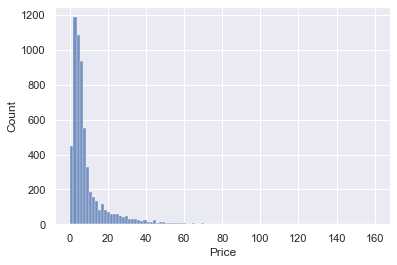

```python
sns.histplot(df["Price"],bins=100)
```

#### The price is heavly skewed on right hand side

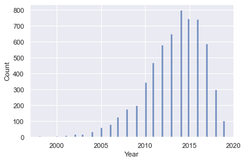

```python
sns.histplot(df["Year"],bins=100)
```

#### Most of the vehicles are from 2006 to 2017. Few are very old can sonsider them as outliers.

#### Year is skewed on left hand side.

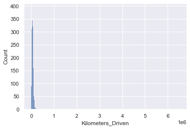

```python
sns.histplot(df['Kilometers_Driven'])
```

#### Kilometers_Driven is skewed on right side.

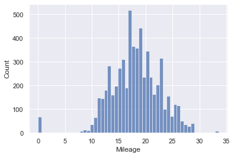

```python
sns.histplot(df['Mileage'])
```

#### The Mielage is close to normally distributed. there are couple on extreme ends (on both sides)

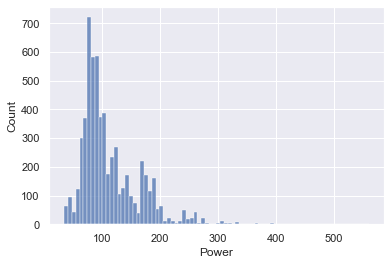

```python
sns.histplot(df['Power'])
```

#### The Power is right-skewedmajaroty of them are around in 100s.

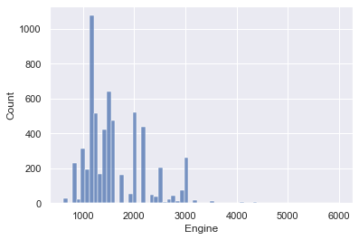

```python
sns.histplot(df['Engine'])
```

#### Engine is right-skewed

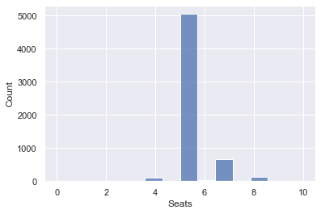

```python
sns.histplot(df['Seats'])
```

#### Most of the cars have seat 5

```
([0, 1, 2, 3, 4, 5, 6, 7, 8, 9, 10],
 [Text(0, 0, ''),
```

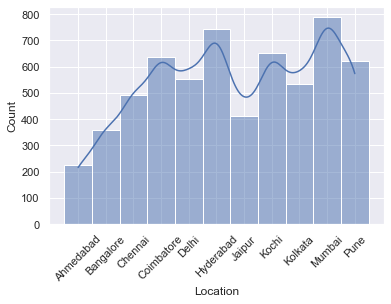

```python
#Location
sns.histplot(df['Location'], kde=True)
plt.xticks(rotation=45)
```

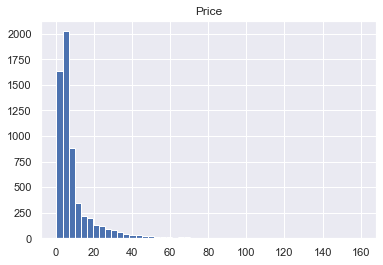

```
0
```

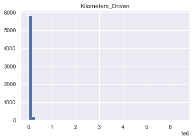

```
0
```

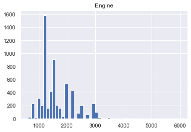

```
0
```

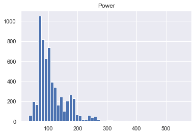

```
0
```

```python
cols_to_log = ['Price','Kilometers_Driven', 'Engine', 'Power']
for colname in cols_to_log:
    plt.hist(df[colname], bins=50)
    plt.title(colname)
    plt.show()
    print(np.sum(df[colname] <= 0))
```

### Looking at few outliers

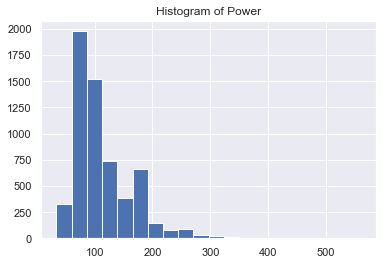

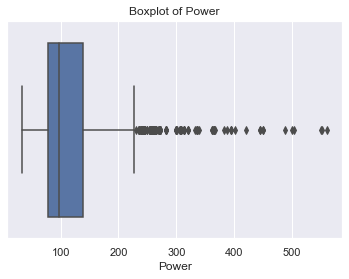

```python
plt.hist(df['Power'], 20)
plt.title('Histogram of Power')
plt.show()

sns.boxplot(df['Power'])
plt.title('Boxplot of Power')
plt.show()
```

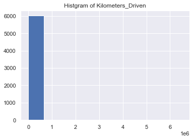

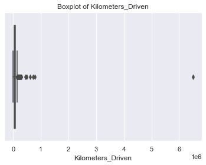

```python
plt.hist(df['Kilometers_Driven'], 10)
plt.title('Histgram of Kilometers_Driven')
plt.show()

sns.boxplot(df['Kilometers_Driven'])
plt.title('Boxplot of Kilometers_Driven')
plt.show()
```

```python
df.loc[df['Kilometers_Driven'] >= 300000]
```

|  | Name | Location | Year | Kilometers_Driven | Fuel_Type | Transmission | Owner_Type | Mileage | Engine | Power | Seats | Price |
| --- | --- | --- | --- | --- | --- | --- | --- | --- | --- | --- | --- | --- |
| 340 | Skoda Octavia Ambition Plus 2.0 TDI AT | Kolkata | 2013 | 775000 | Diesel | Automatic | First | 19.30 | 1968.0 | 141.00 | 5.0 | 7.50 |
| 358 | Hyundai i10 Magna 1.2 | Chennai | 2009 | 620000 | Petrol | Manual | First | 20.36 | 1197.0 | 78.90 | 5.0 | 2.70 |
| 1860 | Volkswagen Vento Diesel Highline | Chennai | 2013 | 720000 | Diesel | Manual | First | 20.54 | 1598.0 | 103.60 | 5.0 | 5.90 |
| 2328 | BMW X5 xDrive 30d M Sport | Chennai | 2017 | 6500000 | Diesel | Automatic | First | 15.97 | 2993.0 | 258.00 | 5.0 | 65.00 |
| 2823 | Volkswagen Jetta 2013-2015 2.0L TDI Highline AT | Chennai | 2015 | 480000 | Diesel | Automatic | First | 16.96 | 1968.0 | 138.03 | 5.0 | 13.00 |
| 3092 | Honda City i VTEC SV | Kolkata | 2015 | 480000 | Petrol | Manual | First | 17.40 | 1497.0 | 117.30 | 5.0 | 5.00 |
| 3649 | Tata Indigo LS | Jaipur | 2008 | 300000 | Diesel | Manual | First | 17.00 | 1405.0 | 70.00 | 5.0 | 1.00 |
| 4490 | Hyundai i20 Magna Optional 1.2 | Bangalore | 2013 | 445000 | Petrol | Manual | First | 18.50 | 1197.0 | 82.90 | 5.0 | 4.45 |

#### Dealing with extreme outlier - BMW was having 6500000 miles driven. This could be typo.

#### I could change the value to 65000 which may be more realistic

#### but wanted to drop rows which has more than 400000 miles on them.

```python
df.drop(df[df['Kilometers_Driven'] >= 400000].index, inplace = True)
```

#### Power, Price and Engine also have outliers but they seems to me reasonable when I looked into data bit deeply.

#### Hence leaving them without handling them.

```python
df.loc[df['Price'] >= 120]
```

|  | Name | Location | Year | Kilometers_Driven | Fuel_Type | Transmission | Owner_Type | Mileage | Engine | Power | Seats | Price |
| --- | --- | --- | --- | --- | --- | --- | --- | --- | --- | --- | --- | --- |
| 4079 | Land Rover Range Rover 3.0 Diesel LWB Vogue | Hyderabad | 2017 | 25000 | Diesel | Automatic | First | 13.33 | 2993.0 | 255.0 | 5.0 | 160.0 |
| 5779 | Lamborghini Gallardo Coupe | Delhi | 2011 | 6500 | Petrol | Automatic | Third | 6.40 | 5204.0 | 560.0 | 2.0 | 120.0 |

```python
df.loc[df['Power'] >= 560.00]
```

|  | Name | Location | Year | Kilometers_Driven | Fuel_Type | Transmission | Owner_Type | Mileage | Engine | Power | Seats | Price |
| --- | --- | --- | --- | --- | --- | --- | --- | --- | --- | --- | --- | --- |
| 5779 | Lamborghini Gallardo Coupe | Delhi | 2011 | 6500 | Petrol | Automatic | Third | 6.4 | 5204.0 | 560.0 | 2.0 | 120.0 |

```python
df.loc[df['Engine'] >= 5500.00]
```

|  | Name | Location | Year | Kilometers_Driven | Fuel_Type | Transmission | Owner_Type | Mileage | Engine | Power | Seats | Price |
| --- | --- | --- | --- | --- | --- | --- | --- | --- | --- | --- | --- | --- |
| 5519 | Bentley Continental Flying Spur | Hyderabad | 2006 | 48000 | Petrol | Automatic | First | 8.6 | 5998.0 | 552.0 | 4.0 | 59.0 |

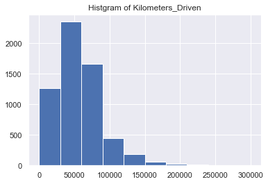

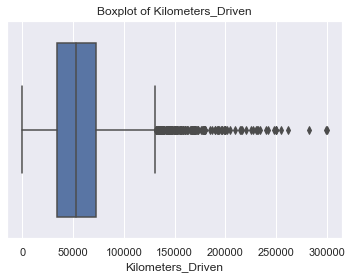

```python
plt.hist(df['Kilometers_Driven'], 10)
plt.title('Histgram of Kilometers_Driven')
plt.show()

sns.boxplot(df['Kilometers_Driven'])
plt.title('Boxplot of Kilometers_Driven')
plt.show()
```

```python
df.describe(include='all').T
```

|  | count | unique | top | freq | mean | std | min | 25% | 50% | 75% | max |
| --- | --- | --- | --- | --- | --- | --- | --- | --- | --- | --- | --- |
| Name | 6010 | 1873 | Mahindra XUV500 W8 2WD | 49 | NaN | NaN | NaN | NaN | NaN | NaN | NaN |
| Location | 6010 | 11 | Mumbai | 789 | NaN | NaN | NaN | NaN | NaN | NaN | NaN |
| Year | 6010.0 | NaN | NaN | NaN | 2013.357903 | 3.270904 | 1998.0 | 2011.0 | 2014.0 | 2016.0 | 2019.0 |
| Kilometers_Driven | 6010.0 | NaN | NaN | NaN | 57143.479368 | 33775.774691 | 171.0 | 34000.0 | 53000.0 | 73000.0 | 300000.0 |
| Fuel_Type | 6010 | 4 | Diesel | 3201 | NaN | NaN | NaN | NaN | NaN | NaN | NaN |
| Transmission | 6010 | 2 | Manual | 4295 | NaN | NaN | NaN | NaN | NaN | NaN | NaN |
| Owner_Type | 6010 | 4 | First | 4920 | NaN | NaN | NaN | NaN | NaN | NaN | NaN |
| Mileage | 6010.0 | NaN | NaN | NaN | 18.134614 | 4.584616 | 0.0 | 15.155 | 18.15 | 21.1 | 33.54 |
| Engine | 6010.0 | NaN | NaN | NaN | 1621.326947 | 599.318665 | 624.0 | 1198.0 | 1493.0 | 1975.75 | 5998.0 |
| Power | 6010.0 | NaN | NaN | NaN | 112.880581 | 53.27457 | 34.2 | 78.0 | 97.7 | 138.03 | 560.0 |
| Seats | 6010.0 | NaN | NaN | NaN | 5.277205 | 0.806879 | 0.0 | 5.0 | 5.0 | 5.0 | 10.0 |
| Price | 6010.0 | NaN | NaN | NaN | 9.47215 | 11.172289 | 0.44 | 3.5 | 5.635 | 9.95 | 160.0 |

# Bivariate Analysis

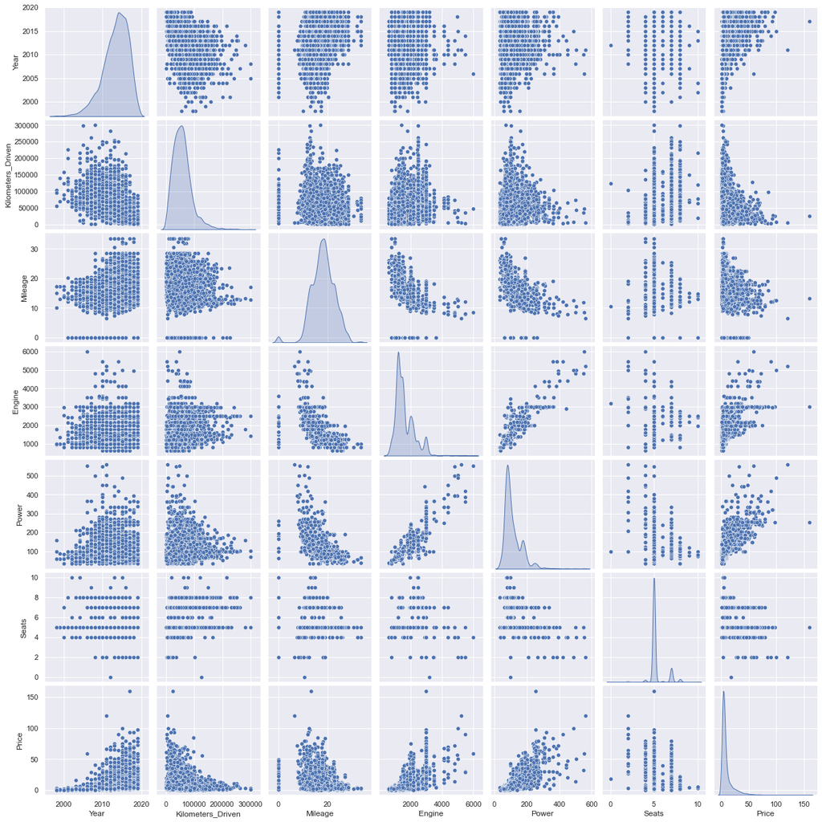

```python
sns.pairplot(df,diag_kind='kde')
#a density curve (BiVarite Plots)
# The observation is between price and other attributes indicate the relationship is not linear.
#But year, mileage, KM driven have influance on. price.
```

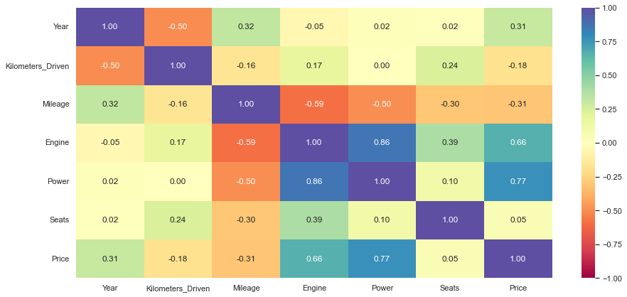

```python
plt.figure(figsize=(15, 7))
sns.heatmap(df.corr(), annot=True, vmin=-1, vmax=1, fmt=".2f", cmap="Spectral")
plt.show()
```

#### Kolometeres, Mileage driven are negatively correlated

```python
# I want to check which makers cars have higher price without considering their models.
df['Maker'] = df['Name'].str.split(" ").str[0]
df[['Maker', 'Name']].head()
df['Maker'].value_counts()
#Maruthi and Hyundai are ranking top in terms of avaialability. Customers may have more bargain in these two types.
# Cars4 should consider discounts to sell these cars.
```

```
Maruti           1211
Hyundai          1105
Honda             607
Toyota            410
Mercedes-Benz     318
Volkswagen        313
Ford              300
Mahindra          271
BMW               266
Audi              236
Tata              186
Skoda             172
Renault           145
Chevrolet         121
Nissan             91
Land               60
Jaguar             40
Fiat               28
Mitsubishi         27
Mini               26
Volvo              21
Porsche            18
Jeep               15
Datsun             13
Force               3
ISUZU               2
Smart               1
Ambassador          1
Isuzu               1
Bentley             1
Lamborghini         1
Name: Maker, dtype: int64
```

```python
#Maker and Models count
df.groupby(['Maker', 'Name']).size()
```

```
Maker       Name
Ambassador  Ambassador Classic Nova Diesel    1
Audi        Audi A3 35 TDI Attraction         1
            Audi A3 35 TDI Premium            1
            Audi A3 35 TDI Premium Plus       1
            Audi A3 35 TDI Technology         1
                                             ..
Volvo       Volvo XC60 D4 Summum              1
            Volvo XC60 D5                     3
            Volvo XC60 D5 Inscription         1
            Volvo XC90 2007-2015 D5 AT AWD    1
            Volvo XC90 2007-2015 D5 AWD       1
Length: 1873, dtype: int64
```

```python
df.groupby("Maker")["Price"].mean().sort_values(ascending=False)
```

```
Maker
Lamborghini      120.000000
Bentley           59.000000
Porsche           48.348333
Land              39.259500
Jaguar            37.632250
Mini              26.896923
Mercedes-Benz     26.809874
Audi              25.537712
BMW               25.093684
Isuzu             20.000000
Volvo             18.802857
Jeep              18.718667
ISUZU             12.045000
Toyota            11.577171
Mitsubishi        11.058889
Force              9.333333
Mahindra           8.027638
Skoda              7.559419
Ford               6.889400
Renault            5.799034
Honda              5.412422
Hyundai            5.346633
Volkswagen         5.280799
Nissan             4.738352
Maruti             4.517267
Tata               3.562849
Fiat               3.269286
Datsun             3.049231
Chevrolet          3.044463
Smart              3.000000
Ambassador         1.350000
Name: Price, dtype: float64
```

#### Lamborghini car is way high compared to other compitators.

#### Though Hyundai and Maruthi cars available high, but they are in between 4 to 6 lakhs, they are pretty economical

#### and suite to new customers who wants to buy 1st time car.

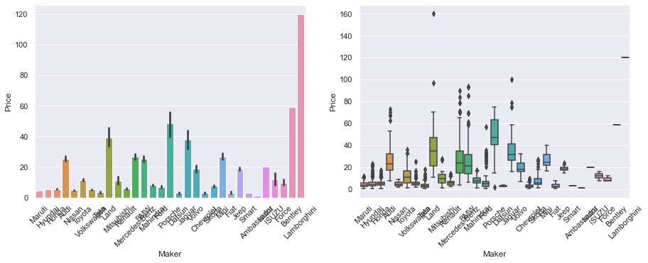

```python
plt.figure(figsize=(15,5))

plt.subplot(1,2,1)
sns.barplot(data=df, y = "Price", x = "Maker")
plt.xticks(rotation = 45)

plt.subplot(1,2,2)
sns.boxplot(data=df, y = "Price", x = "Maker")
plt.xticks(rotation = 45)

plt.show()
```

```python
df.groupby("Location")["Price"].mean().sort_values(ascending=False)
```

```
Location
Coimbatore    15.078223
Bangalore     13.353501
Kochi         11.179186
Hyderabad      9.776550
Delhi          9.707726
Mumbai         9.425120
Ahmedabad      8.457321
Chennai        7.629223
Pune           6.726254
Jaipur         5.809225
Kolkata        5.659006
Name: Price, dtype: float64
```

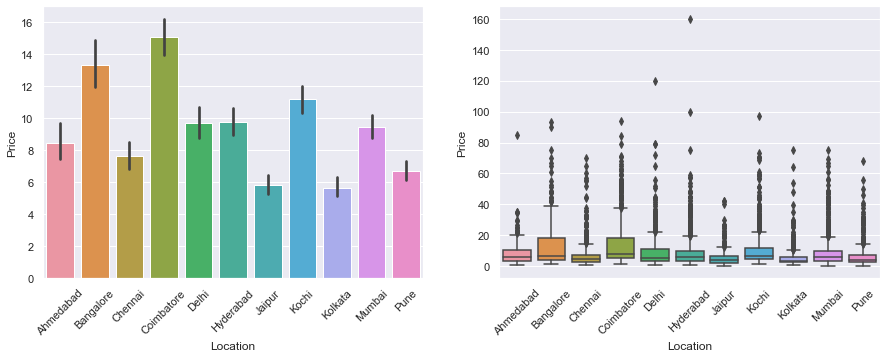

```python
plt.figure(figsize=(15,5))

plt.subplot(1,2,1)
sns.barplot(data=df, y = "Price", x = "Location")
plt.xticks(rotation = 45)

plt.subplot(1,2,2)
sns.boxplot(data=df, y = "Price", x = "Location")
plt.xticks(rotation = 45)

plt.show()
```

#### Coimbatore location buying cars at higher price followed Bangalore.

#### Mumbai location has more inventory and the price is around 10 lakhs range.

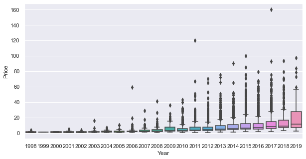

```python
plt.figure(figsize=(10, 5))
sns.boxplot(x="Year", y="Price", data=df)
plt.show()
#The price is higher for the most recent cars
```

#### The latest cars are at higher price, Noted some of them have outliers.

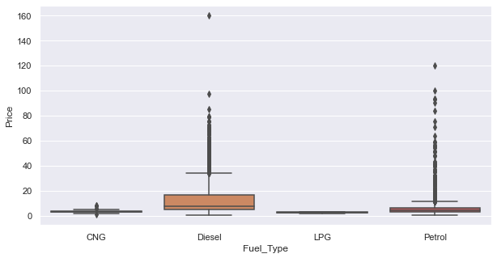

```python
plt.figure(figsize=(10, 5))
sns.boxplot(x="Fuel_Type", y="Price", data=df)
plt.show()
```

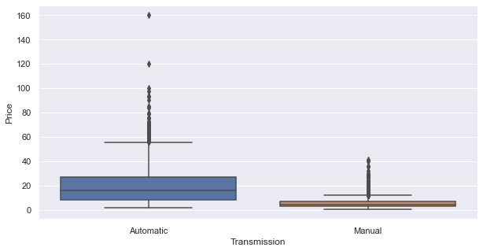

```python
plt.figure(figsize=(10, 5))
sns.boxplot(x="Transmission", y="Price", data=df)
plt.show()
```

#### Automatic Transmission cars can sell at higher price.

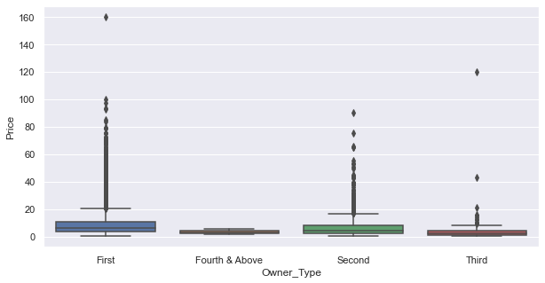

```python
plt.figure(figsize=(10, 5))
sns.boxplot(x="Owner_Type", y="Price", data=df)
plt.show()
```

#### First hand cars are more expensive followed by second hand one

#### first and third hand cars has outliers.

### The below countplots gave similar details described above

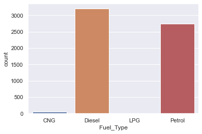

```python
sns.countplot(data = df, x = 'Fuel_Type')
```

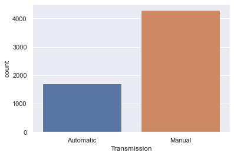

```python
sns.countplot(data = df, x = 'Transmission')
```

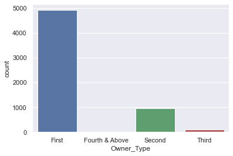

```python
sns.countplot(data = df, x = 'Owner_Type')
```

## Model Building

### Define independent and dependent variables

```python
#Before I make a copy , I want to drop maker column
df.drop(['Maker'],axis=1,inplace=True)
```

```python
df1 =df.copy()
```

```python
# Encoding categorical columns
# Since Location', 'Fuel_Type','Transmission','Owner_Type' are categerial types, creating categorical columns
df1 = pd.get_dummies(df, columns =['Location', 'Fuel_Type','Transmission','Owner_Type'])
df1.head()
```

|  | Name | Year | Kilometers_Driven | Mileage | Engine | Power | Seats | Price | Location_Ahmedabad | Location_Bangalore | Location_Chennai | Location_Coimbatore | Location_Delhi | Location_Hyderabad | Location_Jaipur | Location_Kochi | Location_Kolkata | Location_Mumbai | Location_Pune | Fuel_Type_CNG | Fuel_Type_Diesel | Fuel_Type_LPG | Fuel_Type_Petrol | Transmission_Automatic | Transmission_Manual | Owner_Type_First | Owner_Type_Fourth & Above | Owner_Type_Second | Owner_Type_Third |
| --- | --- | --- | --- | --- | --- | --- | --- | --- | --- | --- | --- | --- | --- | --- | --- | --- | --- | --- | --- | --- | --- | --- | --- | --- | --- | --- | --- | --- | --- |
| 0 | Maruti Wagon R LXI CNG | 2010 | 72000 | 26.60 | 998.0 | 58.16 | 5.0 | 1.75 | 0 | 0 | 0 | 0 | 0 | 0 | 0 | 0 | 0 | 1 | 0 | 1 | 0 | 0 | 0 | 0 | 1 | 1 | 0 | 0 | 0 |
| 1 | Hyundai Creta 1.6 CRDi SX Option | 2015 | 41000 | 19.67 | 1582.0 | 126.20 | 5.0 | 12.50 | 0 | 0 | 0 | 0 | 0 | 0 | 0 | 0 | 0 | 0 | 1 | 0 | 1 | 0 | 0 | 0 | 1 | 1 | 0 | 0 | 0 |
| 2 | Honda Jazz V | 2011 | 46000 | 18.20 | 1199.0 | 88.70 | 5.0 | 4.50 | 0 | 0 | 1 | 0 | 0 | 0 | 0 | 0 | 0 | 0 | 0 | 0 | 0 | 0 | 1 | 0 | 1 | 1 | 0 | 0 | 0 |
| 3 | Maruti Ertiga VDI | 2012 | 87000 | 20.77 | 1248.0 | 88.76 | 7.0 | 6.00 | 0 | 0 | 1 | 0 | 0 | 0 | 0 | 0 | 0 | 0 | 0 | 0 | 1 | 0 | 0 | 0 | 1 | 1 | 0 | 0 | 0 |
| 4 | Audi A4 New 2.0 TDI Multitronic | 2013 | 40670 | 15.20 | 1968.0 | 140.80 | 5.0 | 17.74 | 0 | 0 | 0 | 1 | 0 | 0 | 0 | 0 | 0 | 0 | 0 | 0 | 1 | 0 | 0 | 1 | 0 | 0 | 0 | 1 | 0 |

```python
df1.info()
```

```
<class 'pandas.core.frame.DataFrame'>
Int64Index: 6010 entries, 0 to 6016
Data columns (total 29 columns):
 #   Column                     Non-Null Count  Dtype
---  ------                     --------------  -----
 0   Name                       6010 non-null   object
 1   Year                       6010 non-null   int64
 2   Kilometers_Driven          6010 non-null   int64
 3   Mileage                    6010 non-null   float64
 4   Engine                     6010 non-null   float64
 5   Power                      6010 non-null   float64
 6   Seats                      6010 non-null   float64
 7   Price                      6010 non-null   float64
 8   Location_Ahmedabad         6010 non-null   uint8
 9   Location_Bangalore         6010 non-null   uint8
```

[output cut: 21 more lines]

```python
# At this point dropping Name field since it has many unique names
df1.drop(['Name'],axis=1,inplace=True)
```

```python
#Model Building , defining independent and dependent variables
X = df1.drop(["Price",'Transmission_Manual','Fuel_Type_LPG', 'Owner_Type_Fourth & Above' ,'Location_Ahmedabad','Seats'], axis=1)
y = df1["Price"]
#,"Kilometers_Driven", "Name","Mileage", "Power", "Engine", "Transmission"
```

### Creating dummy Variables

```python
X = pd.get_dummies(
    X,
    columns=X.select_dtypes(include=["object","category"]).columns.tolist(),
    drop_first=True,
)
X.head()
#"object",
```

|  | Year | Kilometers_Driven | Mileage | Engine | Power | Location_Bangalore | Location_Chennai | Location_Coimbatore | Location_Delhi | Location_Hyderabad | Location_Jaipur | Location_Kochi | Location_Kolkata | Location_Mumbai | Location_Pune | Fuel_Type_CNG | Fuel_Type_Diesel | Fuel_Type_Petrol | Transmission_Automatic | Owner_Type_First | Owner_Type_Second | Owner_Type_Third |
| --- | --- | --- | --- | --- | --- | --- | --- | --- | --- | --- | --- | --- | --- | --- | --- | --- | --- | --- | --- | --- | --- | --- |
| 0 | 2010 | 72000 | 26.60 | 998.0 | 58.16 | 0 | 0 | 0 | 0 | 0 | 0 | 0 | 0 | 1 | 0 | 1 | 0 | 0 | 0 | 1 | 0 | 0 |
| 1 | 2015 | 41000 | 19.67 | 1582.0 | 126.20 | 0 | 0 | 0 | 0 | 0 | 0 | 0 | 0 | 0 | 1 | 0 | 1 | 0 | 0 | 1 | 0 | 0 |
| 2 | 2011 | 46000 | 18.20 | 1199.0 | 88.70 | 0 | 1 | 0 | 0 | 0 | 0 | 0 | 0 | 0 | 0 | 0 | 0 | 1 | 0 | 1 | 0 | 0 |
| 3 | 2012 | 87000 | 20.77 | 1248.0 | 88.76 | 0 | 1 | 0 | 0 | 0 | 0 | 0 | 0 | 0 | 0 | 0 | 1 | 0 | 0 | 1 | 0 | 0 |
| 4 | 2013 | 40670 | 15.20 | 1968.0 | 140.80 | 0 | 0 | 1 | 0 | 0 | 0 | 0 | 0 | 0 | 0 | 0 | 1 | 0 | 1 | 0 | 1 | 0 |

```python
X.shape
```

```
(6010, 22)
```

### Split the data into Train and test sets

```python
from sklearn.model_selection import train_test_split

x_train, x_test, y_train, y_test = train_test_split(X, y, test_size=0.3, random_state=1)
```

```python
print("Number of rows in train data =", x_train.shape[0])
print("Number of rows in test data =", x_test.shape[0])
```

```
Number of rows in train data = 4207
Number of rows in test data = 1803
```

### Fitting Linear Regession Model

```python
lin_reg_model = LinearRegression()
lin_reg_model.fit(x_train, y_train)
```

```
LinearRegression()
```

```python
# get the score (R-squared) on the training set

print(
    "The score (R-squared) on the training set is ",
   lin_reg_model.score(x_train, y_train),
)
```

```
The score (R-squared) on the training set is  0.7185048520686579
```

```python
def r_squared(model, X, y):
    y_mean = y.mean()
    SST = ((y - y_mean) ** 2).sum()
    SSE = ((y - model.predict(X)) ** 2).sum()
    r_square = 1 - SSE / SST
    return SSE, SST, r_square


SSE, SST, r_square = r_squared(lin_reg_model, x_train, y_train)
print("SSE: ", SSE)
print("SST: ", SST)
print("R-squared: ", r_square)
```

```
SSE:  142767.2446320011
SST:  507174.7974385073
R-squared:  0.7185048520686579
```

```python
# get the score (R-squared) on the test set

print(
    "The score (R-squared) on the test set is ", lin_reg_model.score(x_test, y_test)
)
```

```
The score (R-squared) on the test set is  0.6871301578885161
```

```python
print(
    "The Root Mean Square Error (RMSE) of the model for the training set is ",
    np.sqrt(mean_squared_error(y_train, lin_reg_model.predict(x_train))),
)
```

```
The Root Mean Square Error (RMSE) of the model for the training set is  5.82543060211209
```

```python
print(
    "The Root Mean Square Error (RMSE) of the model for the test set is ",
    np.sqrt(mean_squared_error(y_test, lin_reg_model.predict(x_test))),
)
```

```
The Root Mean Square Error (RMSE) of the model for the test set is  6.491580206131119
```

```python
coef_df = pd.DataFrame(
    np.append(lin_reg_model.coef_, lin_reg_model.intercept_),
    index=x_train.columns.tolist() + ["Intercept"],
    columns=["Coefficients"],
)
coef_df
```

|  | Coefficients |
| --- | --- |
| Year | 0.744775 |
| Kilometers_Driven | -0.000042 |
| Mileage | -0.128535 |
| Engine | 0.000348 |
| Power | 0.133061 |
| Location_Bangalore | 1.799991 |
| Location_Chennai | 1.231642 |
| Location_Coimbatore | 2.216673 |
| Location_Delhi | -0.656305 |
| Location_Hyderabad | 2.161426 |
| Location_Jaipur | 1.359006 |
| Location_Kochi | 0.275292 |
| Location_Kolkata | -1.502228 |
| Location_Mumbai | -0.871779 |
| Location_Pune | 0.864491 |
| Fuel_Type_CNG | 0.499999 |
| Fuel_Type_Diesel | -0.891369 |
| Fuel_Type_Petrol | -3.403841 |
| Transmission_Automatic | 2.355306 |
| Owner_Type_First | -4.256362 |
| Owner_Type_Second | -4.546488 |
| Owner_Type_Third | -3.625433 |
| Intercept | -1495.846027 |

### Coefficient Interpretations

#### Enginer, Mileage, Owner, location, Mileage, Price should set at lower price to sell more cars

#### Power is positive, This has +ve impact on the price

#### Transmission manual decreases the price

#### if year increases, the price could sell at higher price

#### We can interpret all these values in both ways.Having good power, decent Mileage, Automatic tranmission, fule type (petrol and diesel) are driving variables either to increase or decrease the price of the car.

### Model performace Check

#### I'm going to use functions from the class material to understand the performance of the model

```python
#create a function that will print out all the above metrics in one go.

# function to compute adjusted R-squared
def adj_r2_score(predictors, targets, predictions):
    r2 = r2_score(targets, predictions)
    n = predictors.shape[0]
    k = predictors.shape[1]
    return 1 - ((1 - r2) * (n - 1) / (n - k - 1))


# function to compute MAPE
def mape_score(targets, predictions):
    return np.mean(np.abs(targets - predictions) / targets) * 100


# function to compute different metrics to check performance of a regression model
def model_performance_regression(model, predictors, target):
    """
    Function to compute different metrics to check regression model performance

    model: regressor
    predictors: independent variables
    target: dependent variable
    """

    # predicting using the independent variables
    pred = model.predict(predictors)

    r2 = r2_score(target, pred)  # to compute R-squared
    adjr2 = adj_r2_score(predictors, target, pred)  # to compute adjusted R-squared
    rmse = np.sqrt(mean_squared_error(target, pred))  # to compute RMSE
    mae = mean_absolute_error(target, pred)  # to compute MAE
    mape = mape_score(target, pred)  # to compute MAPE

    # creating a dataframe of metrics
    df_perf = pd.DataFrame(
        {
            "RMSE": rmse,
            "MAE": mae,
            "R-squared": r2,
            "Adj. R-squared": adjr2,
            "MAPE": mape,
        },
        index=[0],
    )

    return df_perf
```

```python
# Checking model performance on train set
print("Training Performance\n")
lin_reg_model_train_perf = model_performance_regression(lin_reg_model, x_train, y_train)
lin_reg_model_train_perf
```

```
Training Performance
```

|  | RMSE | MAE | R-squared | Adj. R-squared | MAPE |
| --- | --- | --- | --- | --- | --- |
| 0 | 5.825431 | 3.631598 | 0.718505 | 0.717025 | 71.796886 |

```python
# Checking model performance on test set
print("Test Performance\n")
lin_reg_model_test_perf = model_performance_regression(lin_reg_model, x_test, y_test)
lin_reg_model_test_perf
```

```
Test Performance
```

|  | RMSE | MAE | R-squared | Adj. R-squared | MAPE |
| --- | --- | --- | --- | --- | --- |
| 0 | 6.49158 | 3.653759 | 0.68713 | 0.683263 | 73.115588 |

#### This shows that the model is underfitting.

## Conclusions

#### Like I mentioned in the beginning

#### it is hard to a set up right price for all the makes and models.

#### It is very hard to recommend unique price across all makes, models and locations.

#### Each city location dealer should come up with their own price model based on the above statistics.

#### But in general they can start pricing their cars above .44 lakhs regardless of the location, year, make etc..

#### This is not recommended price , but just a statistical view to give confidence.

#### Probably non-linear transformation may improve the performance of the above regression model

```python
#Equation of linear regression

Equation = "Price = " + str(lin_reg_model.intercept_)
print(Equation, end=" ")

for i in range(len(x_train.columns)):
    if i != len(x_train.columns) - 1:
        print(
            "+ (",
            lin_reg_model.coef_[i],
            ")*(",
            x_train.columns[i],
            ")",
            end="  ",
        )
    else:
        print("+ (", lin_reg_model.coef_[i], ")*(", x_train.columns[i], ")")
```

```
Price = -1495.8460270364299 + ( 0.7447749978232643 )*( Year )  + ( -4.245256923676904e-05 )*( Kilometers_Driven )  + ( -0.1285352597559969 )*( Mileage )  + ( 0.0003475060536578229 )*( Engine )  + ( 0.1330606392414648 )*( Power )  + ( 1.7999911920857352 )*( Location_Bangalore )  + ( 1.231641754671000…
```